[figure not shown]

Det samhällsekonomiska läget i Dalarna

# Det samhällsekonomiska läget i Dalarna

Rapporten är skapad av Samhällsanalys, Region Dalarna  
Senast uppdaterad: 2026-10-30

# Sammanfattning

Denna rapport ger en bild av läget i Dalarna med fokus på den ekonomiska utvecklingen. Rapporten uppdateras regelbundet och ett antal viktiga trender och mönster sammanfattas här:

- Konjunkturinstitutets barometerindikator visar på ett starkare stämningsläge än normalt i den svenska ekonomin i oktober 2026. Stämningsläget bland hushållen försämrades dock kraftigt jämfört med månaden innan.
- Inflationen i september 2026 var 1,5 procent, vilket var en tydlig ökning jämfört med månaderna innan. Inflationen är dock fortfarande lägre än Riksbankens inflationsmål.
- Priserna på småhus i Dalarna ökade något i september 2026, jämfört med månaden innan.
- Antalet nystartade företag i Dalarna var något lägre under andra kvartalet 2026 än kvartalet innan, men klart högre än under kvartalen dessförinnan.
- Antalet konkurser i Dalarna minskade i september 2026, jämfört med motsvarande månad året innan.
- Antalet nyregisteringar av personbilar ökade i Dalarna i september 2026, jämfört med motsvarande månad året innan.
- Arbetslösheten i Dalarna, klart under genomsnittet i Sverige, har minskat hittills under 2026, jämfört med motsvarande månader åren innan.
- Antalet personer med ekonomiskt stöd som huvudsaklig inkomstkälla har minskat i Dalarna på senare år. Minskningen är framförallt koncentrerad till utrikes födda.

# Introduktion

I Sverige har vi tillgång till mycket god statistik om både våra levnadsförhållanden och vår ekonomi. Det innebär att vi också kan följa upp bland annat den ekonomiska utvecklingen i närtid, både regionalt och nationellt, till exempel vad gäller ekonomisk aktivitet (BNP), sysselsättning och bostadsbyggande. De senaste årens omvälvande händelser i världen – covid-19-pandemin, Rysslands invasion av Ukraina och flera konflikter i Mellanöstern – är förödande för dem som står i händelsernas centrum, men de drabbar även oss. Dessa händelser sätter prägel på både vår ekonomi och våra levnadsförhållanden, och gör det än mer angeläget att följa den ekonomiska utvecklingen regionalt och nationellt.  
Region Dalarnas samhällsanalytiker har därför tagit fram denna rapport i syfte att ge en nulägesbild över hur läget utvecklas i Dalarna. Rapporten kommer att uppdateras regelbundet. Fokus ligger i första hand på att synliggöra det ekonomiska läget i Dalarna, exempelvis hur arbetsmarknad och bostadsbyggande utvecklas i regionen. Men många faktorer som påverkar Dalarnas ekonomi är nationella, och därför startar analysen med att diskutera läget i Sverige i stort och de faktorer som ramar in förutsättningarna för oss som bor och vistas i Dalarna.

# 1 Det allmänna läget i ekonomin

Det allmänna läget i en ekonomi kan beskrivas på flera sätt. I detta första avsnitt har vi valt att fokusera på tre variabler: bruttoregionalprodukt (hädanefter BNP), konjunkturbarometern och inflation.

## 1.1 BNP

**Mer information om statistiken**

BNP mäts till marknadspris från användningssidan (ENS2010). Data är säsongsrensad och på kvartalsbasis (i fasta priser, dvs. justerad för inflation). BNP är ett mått på den totala ekonomiska aktiviteten i ett land under en tidsperiod. För en mer övergripande förklaring av Sveriges BNP och dess utveckling se SCB:s [snabba fakta](https://www.scb.se/hitta-statistik/sverige-i-siffror/samhallets-ekonomi/bnp-i-sverige/).

I kvartal två 2026 var förändringen i BNP 1,6 procent, dvs. aktiviteten i Sveriges ekonomi ökade tydligt jämfört med kvartalet innan. Det var dessutom den största ökningen under ett enskilt kvartal sedan 2024. För en diskussion om vad som påverkade BNP under kvartal två 2026, se [SCB](https://www.scb.se/hitta-statistik/statistik-efter-amne/nationalrakenskaper/nationalrakenskaper/nationalrakenskaper-kvartals-och-arsberakningar/pong/statistiknyhet/nationalrakenskaper-2a-kvartalet-2026/).

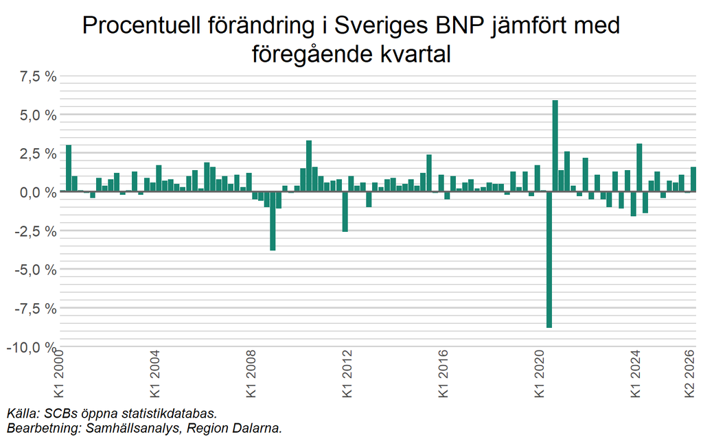

Konjunkturinstitutet sammanställer på sin [hemsida](https://www.konj.se/publikationer/prognosjamforelse/) ett urval av aktuella prognoser för bland annat BNP (på helårsbasis). För år 2026 tror prognosinstituten i genomsnitt på en ökning av aktiviteten i Sveriges ekonomi på ungefär 2,6 procent, medan förväntningarna för år 2027 är något lägre (en ökning med cirka 2,5 procent).

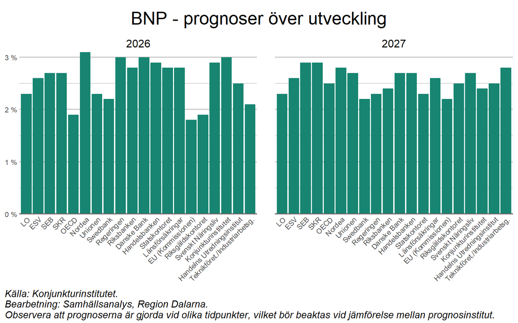

## 1.2 Konjunkturbarometern

Ett annat sätt att mäta läget i ekonomin är genom de olika enkätundersökningar som Konjunkturinstitutet regelbundet genomför, med frågor till företag och hushåll om deras uppfattning om nuläge och deras förväntningar på den ekonomiska utvecklingen. Svaren vägs samman i en indikator som kallas Konjunkturbarometern. Till skillnad från BNP fokuserar konjunkturbarometern inte enbart på nuläget, utan hushållen och företagen får även svara på frågor som rör framtidsutsikterna. Barometerindikatorn väger samman konfidensindikatorer från svaren i de olika enkäterna och ger varje månad en bild av konjunkturläget i Sveriges ekonomi.

**Mer information om statistiken**

Barometerindikatorn sammanfattar konfidensindikatorer för tillverkningsindustri, tjänstesektorn, byggindustri, handel samt hushållen i Sverige. Indikatorerna baseras på enkätsvar från företag om bland annat deras produktion, investeringar och försäljning, men även företagens planer och förväntningar om framtiden, tillsammans med hushållens svar på enkätfrågor om deras ekonomiska situation nu och deras planer och förväntningar för framtiden. Detta sammanfattas i Konjunkturbarometern. Barometerindikatorn kan närmast jämföras med EU-kommissionens Economic Sentiment Indicator (ESI) och har ett medelvärde på 100 och en standardavvikelse på 10. Värden över 100 motsvarar en starkare ekonomi än normalt, och värden över 110 en mycket starkare. Värden under 100 visar på en svagare ekonomi än normalt, och värden under 90 en mycket svagare.

### Generellt

I oktober 2026 var barometerindikatorn 108,1, vilket var något högre än månaden innan. Indikatorn visar på ett starkare stämningsläge än normalt i den svenska ekonomin (se [Konjunkturinstitutet](https://www.konj.se/publikationer/konjunkturbarometern/2026-10-29-stort-fall-i-hushallens-stamningslage/)).

Att barometerindikatorn under en period hade ett lågt värde kan delvis förklaras av Rysslands invasion av Ukraina och de effekter denna haft på bland annat tillgången på råvaror. Historiskt varierar barometerindikatorn med konjunkturen. Större kriser i samhället, såsom finanskrisen 2008/2009 och coronapandemin 2020/2021, syns tydligt i diagrammet.

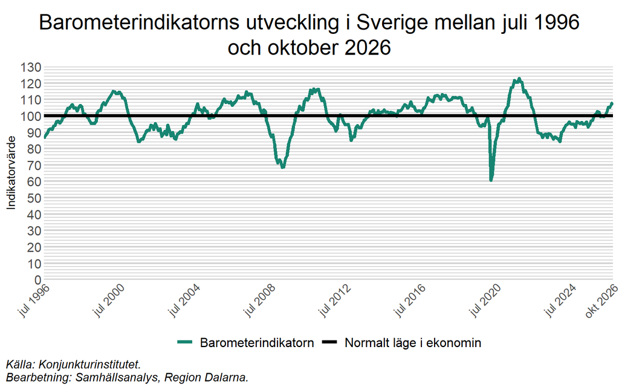

### Bransch

Hur läget i ekonomin uppfattas varierar beroende på om det är företagen eller hushållen som tillfrågas. Hushållens syn på ekonomin försämrades kraftigt i oktober 2026 jämfört med månaden innan (en barometerindikator på 94,3), och kan beskrivas som sämre än normalt (se [Konjunkturinstitutet](https://www.konj.se/publikationer/konjunkturbarometern/2026-10-29-stort-fall-i-hushallens-stamningslage/)).

Stämningsläget är starkare än normalt i samtliga branschgrupper i diagrammet nedan. Den mest positiva synen på ekonomin (betydligt starkare än normalt) hade tillverkningsindustri i oktober 2026 (en barometerindikator på 111,5). Även inom handel är stämningslaget betydligt starkare en normalt.

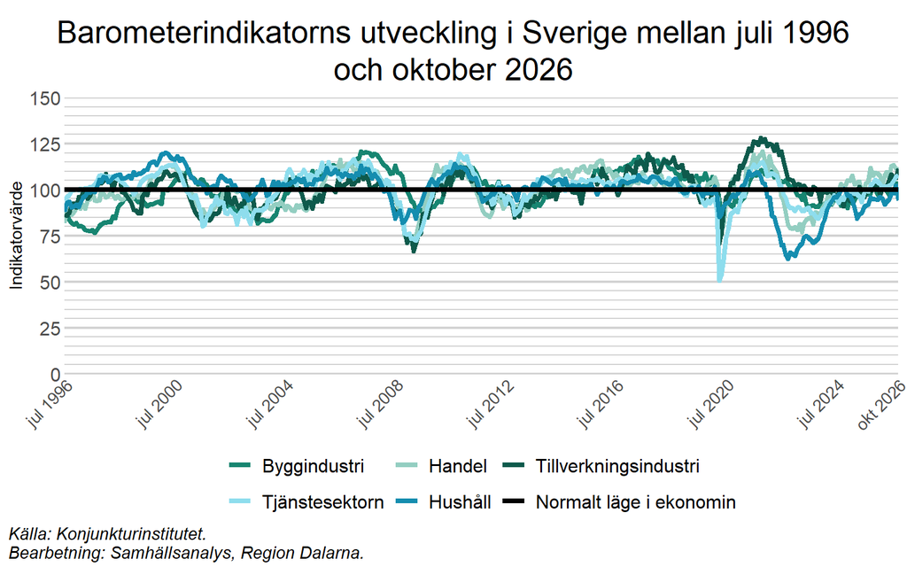

## 1.3 Inflation

Ytterligare en faktor som är viktig för ett lands ekonomi är förändringen i den allmänna prisnivån, så kallad inflation. Normalt förknippas hög inflation med problem, eftersom varor och tjänster blir dyrare. Om inte lönerna ökar i samma takt blir människor fattigare i reala termer, vilket har blivit påtagligt i Sverige de senaste åren. Även låg, eller negativ, inflation kan vara skadligt för ekonomin. Exempelvis missgynnas låntagare av en sjunkande prisnivå, då skulden ökar i reala termer. Sveriges Riksbank strävar därför efter att hålla inflationen relativt konstant över tid, runt ett uttalat inflationsmål.

**Mer information om statistiken**

Det vanligaste och mest kända sättet att mäta inflationen i Sverige är att titta på förändringen i konsumentprisindex, KPI. Under senare tid har dock måttet kompletterats med en variant som håller räntenivån fast, kallad KPIF. Anledningen är att räntan kan påverka prisnivån indirekt, framförallt genom boendekostnader. Konsumentprisindex med fast ränta, KPIF, beräknas med samma data och på samma sätt som KPI, men utan att effekten av ändrade räntor räknas med. Indexet visar hur mycket det kostar att leva i Sverige och hur denna kostnad har utvecklats över tid. Målet för Riksbankens penningpolitik är att inflationen ska vara 2 procent. Ett viktigt skäl till den tydliga målsättningen är att skapa trygghet och långsiktighet för företag och hushåll i deras ekonomiska beslut.

Sedan Riksbankens inflationsmål infördes 1993 har inflationen, mätt som årsförändring i KPIF, legat klart under inflationsmålet på 2 procent under långa perioder. Från sin bottennivå i april 2020 ökade dock inflationen väldigt mycket och var som högst i december 2022, då den i Sverige uppgick till 10,2 procent. Därefter har inflationen minskat avsevärt och var i september 2026 1,5 procent, vilket dock var tydligt högre än månaderna innan. För en mer ingående förklaring av vad som påverkade inflationstakten i september 2026, se [SCB](https://www.scb.se/hitta-statistik/statistik-efter-amne/priser-och-ekonomiska-tendenser/priser/konsumentprisindex-kpi/pong/statistiknyhet/konsumentprisindex-kpi-september-2026/).

Den höga inflationstakten under framförallt 2022 och 2023 har ett antal olika förklaringar, däribland begränsningar i utbudet av varor när världen öppnade upp efter coronapandemin och Rysslands invasion av Ukraina. Läs mer på [Wikipedia](https://en.wikipedia.org/wiki/2021%E2%80%932023_inflation_surge).

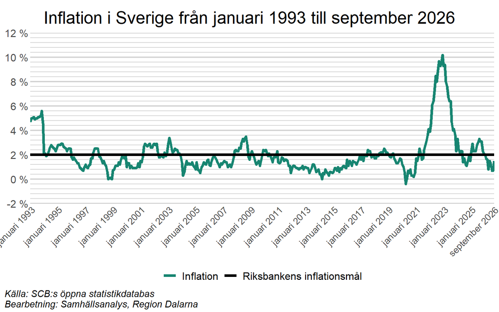

Konjunkturinstitutet sammanställer på sin [hemsida](https://www.konj.se/publikationer/prognosjamforelse/) ett urval av aktuella prognoser för inflation (enligt KPIF). För år 2026 är det vissa skillnader mellan prognoserna, men en majoritet av prognosinstituten tror att inflationen enligt KPIF kommer att vara mellan 1 och 1,5 procent, vilket är lägre än Riksbankens inflationsmål. Året efter är prognoserna generellt högre: en majoritet av instituten tror på mellan 1,5 och 2 procents inflation.

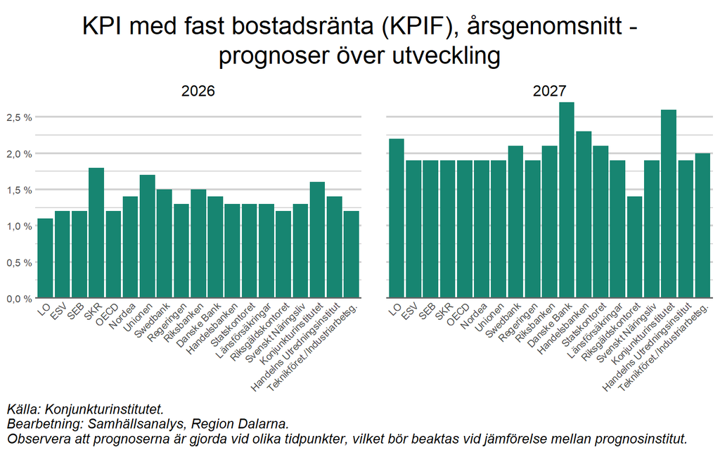

Sedan sommaren 2024 har Riksbanken sänkt sin styrränta ett flertal gånger (den ligger nu på 1,75 procent). Detta påverkar räntorna på exempelvis bostadslån ([SCB](https://www.scb.se/hitta-statistik/statistik-efter-amne/finansmarknad/finansmarknadsstatistik/finansmarknadsstatistik/pong/statistiknyhet/finansmarknadsstatistik-september-2026/)). I jämförelse med framförallt andra hälften av 2010-talet är dock styrräntan fortfarande relativt hög (se exempelvis [Ekonomifakta](https://www.ekonomifakta.se/sakomraden/finansiell-ekonomi/inflation-och-styrrantor/styrrantan_1208883.html)). Vid sitt senaste möte (september 2026) valde Riksbankens direktion att lämna styrräntan oförändrad, men bedömer att höjningar av räntan kommer att inledas senare under året om inflations- och konjunkturutsikterna står sig ([Riksbanken](https://www.riksbank.se/sv/press-och-publicerat/nyheter-och-pressmeddelanden/pressmeddelanden/2026/styrrantan-oforandrad-pa-175-procent6/)).

# 2 Bostadsmarknaden

2010-talet kännetecknades av en bostadsmarknad där det mesta pekade uppåt. Låg inflation och låga räntor i kombination med fördelaktiga skatteregler medförde att såväl byggandet av bostäder, som bostadspriserna ökade kraftigt. Nationellt har bostadslånen ökat under en lång period och uppgick i Sverige 2025 till ungefär 160 procent av hushållens disponibla inkomst, vilket är nästan dubbelt så stor andel som under mitten av 1990-talet. Samtidigt har hushållens finansiella tillgångar ökat, vilket medfört att skulderna i relation till de finansiella tillgångarna minskat något under samma period [(SCB)](https://www.scb.se/hitta-statistik/temaomraden/sveriges-ekonomi/konjunkturindikatorer/finansmarknad/#62307). Det kan naturligtvis finnas skillnader regionalt, men vi saknar data för detta i nuläget.

## 2.1 Bostadsbyggande

**Mer information om statistiken**

Småhus definieras som friliggande en- och tvåbostadshus samt par-, rad- och kedjehus (exklusive fritidshus).

Notera att det finns en eftersläpning i statistiken. För bygglov gör eftersläpningen att de senaste fyra kvartalens siffror är underskattade. Störst är underskattningen det senaste kvartalet.

För påbörjade småhus är statistiken preliminär och underskattningen det senaste kvartalet mellan 20 och 60 procent beroende på kvartal, och är som störst för andra kvartalet. Efter ett år är underskattningen cirka 2 procent.

### Bygglov

Antalet godkända bygglov för småhus i Dalarna varierar mellan kvartalen, men sedan toppen i kvartal två 2022, då 149 bygglov godkändes, har antalet minskat och i kvartal två 2026 godkändes 41 bygglov. Notera dock att det finns en eftersläpning i statistiken, vilket medför att de senaste kvartalens siffror sannolikt kommer att revideras upp. Se ‘Mer information om statistiken’ ovan.

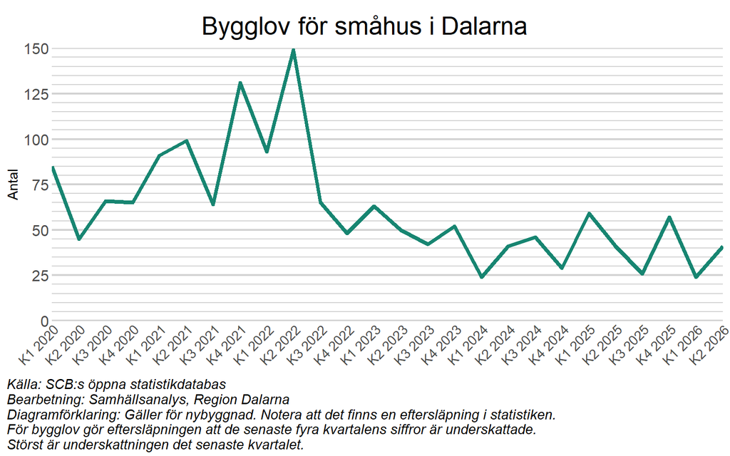

### Nybyggnation

Precis som för byggloven varierar byggandet av småhus mellan kvartalen, men en långsiktig trend är att byggandet har minskat tydligt från toppen i kvartal två 2022, då 137 småhus påbörjades. I kvartal två 2026 påbörjades 46 småhus, vilket dock var fler än kvartalet innan. Notera dock att det finns en eftersläpning i statistiken, vilket medför att de senaste kvartalens siffror sannolikt kommer att revideras upp. Se ‘Mer information om statistiken’ ovan.

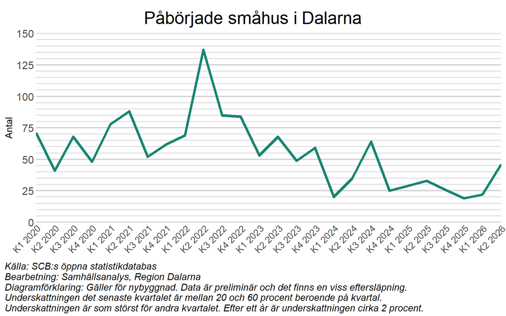

## 2.2 Bostadspriser

**Mer information om statistiken**

Noteringen om månad avser i själva verket en tremånadersperiod, där noteringen avser den sista månaden i perioden.

### Historisk jämförelse

Priserna på småhus ökade stadigt under en lång period, såväl i Dalarna som i Sverige (se diagrammet nedan, där prisutvecklingen visas som ett index med januari 2010 som startvärde 100). Efter toppen i januari 2022, då ett småhus i Dalarna kostade ungefär 3 miljoner kronor, har dock det genomsnittliga priset på småhus i länet minskat avsevärt och en botten nåddes i oktober 2023, när det kostade strax under 2,1 miljoner kronor i genomsnitt. Den tydliga minskningen kan delvis förklaras av Rysslands invasion av Ukraina, vilken bland annat medförde en kraftigt ökad inflation med efterföljande räntehöjningar, något som påverkade efterfrågan på bostäder.

Sedan 2023 har priserna på småhus i Dalarna delvis återhämtat sig och var i september 2026 drygt 2,4 miljoner kronor i genomsnitt, vilket var något högre än månaden innan.

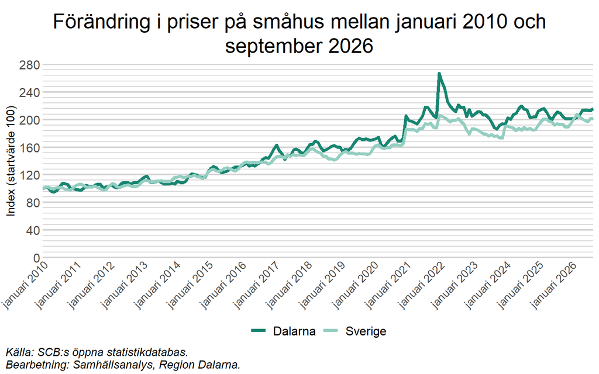

### Län

Det genomsnittliga priset på ett småhus varierar mellan Sveriges län och var i september 2026 högst i Stockholm, där ett småhus i genomsnitt kostade 7,2 miljoner kronor. I Dalarna var priset klart lägre, i genomsnitt drygt 2,4 miljoner kronor, vilket också var klart under riksgenomsnittet. Av förklarliga skäl är bostadspriserna i normala fall högst i län med större städer, medan det omvända gäller för län med en mindre befolkning.

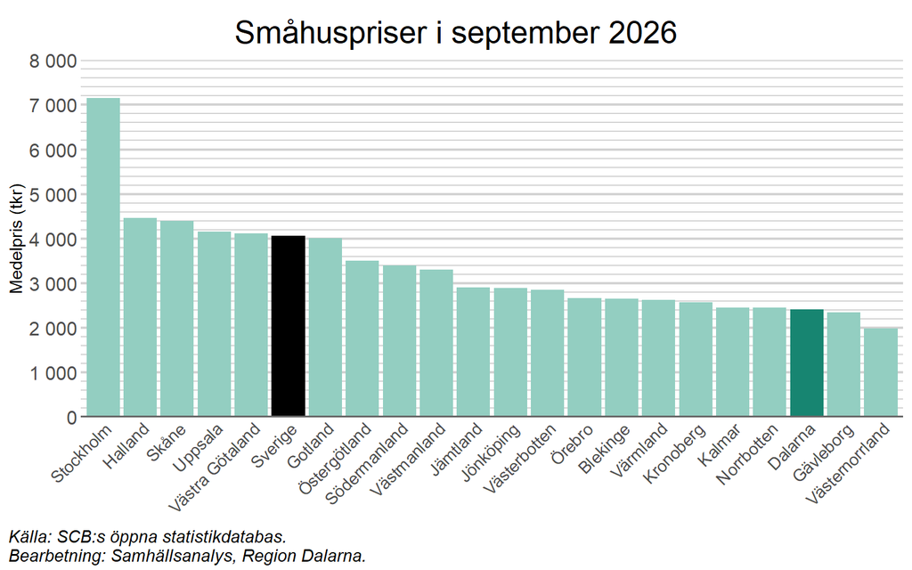

# 3 Företagande och ekonomisk aktivitet

Läget för företagen i länet hänger naturligtvis samman med läget i ekonomin i stort. Vid sämre tider konsumerar hushållen mindre och efterfrågan på många företags produkter och tjänster minskar, vilket i förlängningen kan leda till att företag går i konkurs. Sämre tider kan också göra det mindre attraktivt att starta nya företag. Även hushållens och företagens benägenhet att konsumera sällanköpsvaror, såsom nya bilar, påverkas av konjunkturen, eftersom hushåll kan skjuta upp konsumtion av den typen av varor när konjunkturen försvagas (se exempelvis [ECB](https://www.ecb.europa.eu/press/economic-bulletin/articles/2020/html/ecb.ebart202005_01~7749d3224d.en.html)).

I det här avsnittet undersöks först hur många nya företag som startas i Dalarna, därefter antalet konkurser i länet och slutligen hur många nya personbilar som registreras.

## 3.1 Nystartade företag

**Mer information om statistiken**

Statistiken beskriver mängden genuint nystartade företag. Med genuint nystartade företag menas företag som är helt nybildade eller har återupptagits efter att ha varit vilande i minst två år. Företag som nyregisteras på grund av ägarskiften, ändring av juridisk form eller annan ombildning exkluderas. Från och med 2011 är statistiken registerbaserad.

Historiskt startades väldigt många företag i samband med coronapandemin 2020-2021. I kvartal två 2021 startades exempelvis 506 företag, vilket var det största antalet sedan åtminstone 2011. Exakt vad detta beror på kan vara svårt att säga, men en potentiell förklaring är att individer som blev uppsagda under pandemin valde att starta egna företag. Någon större trend sedan Rysslands invasion av Ukraina märktes inte initialt för antalet nystartade företag. Under 2022 startades till och med något fler företag än genomsnittet sedan 2011. Under första halvan av 2023 märktes dock en viss avmattning, innan antalet återigen började öka. I kvartal två 2026 startades 467 företag, vilket var 37 färre än föregående kvartal men klart fler än kvartalen dessförinnan.

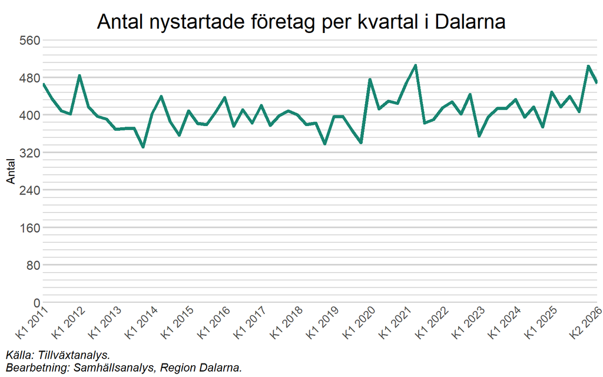

## 3.2 Konkurser

### Månad

Konkurserna redovisas både per månad och per år (se flikarna ovan). Månadsdiagrammet visar den kortsiktiga rörelsen med en utjämnad trend, medan årsdiagrammet ger en tydligare bild av de långsiktiga svängningarna kopplade till konjunktur och kriser.

Statistiken täcker företagskonkurser, det vill säga att ett företag försätts i konkurs, oavsett företagsform (inklusive enskilda näringsidkare). Antalet konkurser i Dalarna varierar relativt mycket från månad till månad, vilket gör det svårt att utläsa någon tydlig utveckling från enskilda månader. Den utjämnade trendlinjen i diagrammet visar däremot hur den underliggande nivån har rört sig över tid.

Sett över hela perioden har antalet konkurser rört sig i tydliga vågor som följer konjunkturen, med högre nivåer i svagare tider och lägre i starkare. Trenden sjönk under mitten av 2000-talet, steg efter finanskrisen och har de senaste åren vänt uppåt igen.

I september 2026 inträffade 10 konkurser, vilket var färre än de 19 som inträffade motsvarande månad 2025.

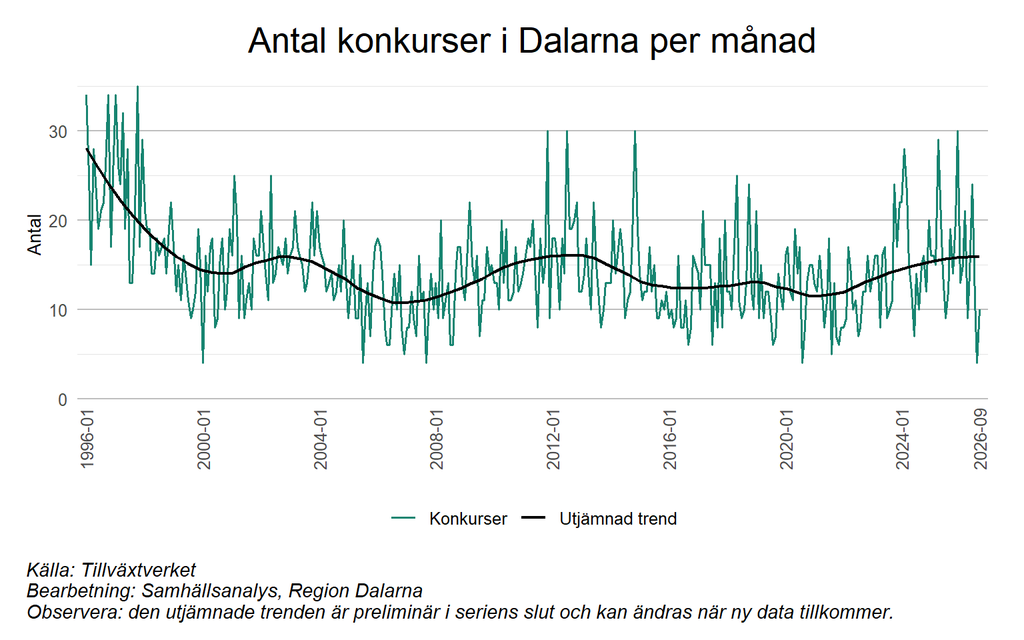

### År

Antalet konkurser i Dalarna varierar relativt mycket även från år till år, men tenderar att öka till följd av större ekonomiska kriser i samhället. Antalet var som högst i början av perioden, med 289 konkurser 1996 och 291 år 1997. Detta speglar sannolikt efterverkningarna av den djupa ekonomiska kris som drabbade Sverige i början av 1990-talet, även om statistiken inte sträcker sig längre tillbaka än 1996. En mindre uppgång syns kring 2002–2003 i samband med IT-bubblan, och antalet var förhöjt även under åren efter finanskraschen 2008–2009. På senare år har antalet ökat, framförallt sedan 2022. Detta hänger sannolikt delvis samman med Rysslands invasion av Ukraina och de effekter denna haft på Sveriges ekonomi (se avsnitt 1, “Det allmänna läget i ekonomin”, ovan). En annan potentiell förklaring är att företag under coronapandemin (2020–2021) gavs möjlighet att skjuta upp sin betalning av skatter, ett anstånd som förlängdes under energikrisen. När de uppskjutna skatterna ska betalas, riskerar det leda till att företag går i konkurs [(SVT)](https://www.svt.se/nyheter/ekonomi/staten-kan-ga-miste-om-24-miljarder-efter-pandemin-allt-storre-foretag-gar-i-konkurs).

Hittills under 2026 har 121 konkurser inträffat i Dalarna, vilket är klart färre än de 150 som inträffade under motsvarande period 2025.

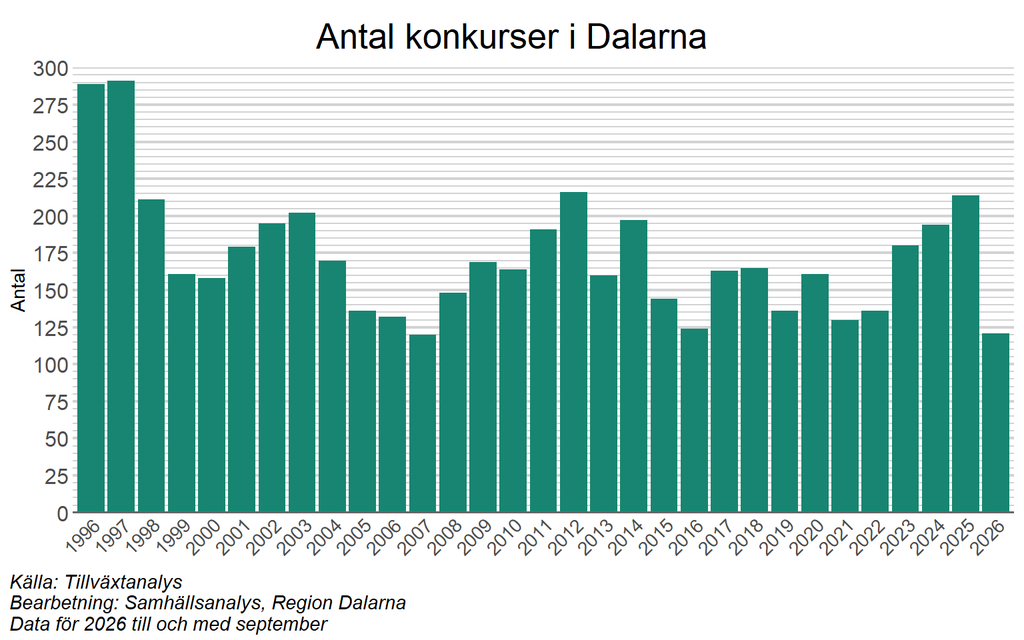

Utöver konkurser avregistreras årligen omkring 1 000 företag i Dalarna, men detta följer inget tydligt konjunkturmönster.

## 3.3 Nyregistrerade personbilar

Antalet nyregistrerade personbilar är en indikator som tenderar att påverkas av konjunkturen (se exempelvis [Mobility Sweden](https://mobilitysweden.se/statistik/Nyregistreringar_per_manad_1/nyregistreringar-2024/svagt-fordonsar-2024-med-okade-utslapp-men-viss-ljusning-2025)). SCB använder av samma skäl nyregistrerade fordon som en av indikatorerna i sin nationella [konjunkturklocka](https://www.scb.se/hitta-statistik/temaomraden/sveriges-ekonomi/konjunkturklocka/). Det är dock viktigt att ha i åtanke att försäljning av personbilar även påverkas av faktorer som inte nödvändigtvis är kopplade till konjunkturen, såsom skatter och förändrade regler. Mer om det nedan.

### Månad

Nyregistreringarna redovisas både per månad och per år (se flikarna ovan). Månadsdiagrammet visar den kortsiktiga rörelsen med en utjämnad trend, medan årsdiagrammet ger en tydligare bild av de långsiktiga förändringarna.

Antalet nyregistrerade personbilar i Dalarna varierar mycket från månad till månad, vilket gör det svårt att utläsa någon tydlig utveckling från enskilda månader. Den utjämnade trendlinjen i diagrammet visar däremot hur den underliggande nivån har rört sig över tid.

Efter en kraftig nedgång i samband med finanskrisen 2008–2009 steg antalet nyregistreringar och nådde en topp omkring 2016–2017, för att därefter sjunka tillbaka. På senare år har nivån legat lägre än under mitten av 2010-talet, men en viss ökning kan skönjas på sistone.

De kraftiga topparna 2018 och 2019 beror på införandet av och regeländringar i det så kallade bonus malus-systemet, som ledde till att många bilar registrerades strax innan skatteförändringar trädde i kraft (se [Mobility Sweden](https://mobilitysweden.se/statistik/Nyregistreringar_per_manad_1/nyregistreringar-2018/basta-registreringsmanaden-nagonsin-for-nya-fordon) och [SVT](https://www.svt.se/nyheter/ekonomi/bilaret-2019)). Dessa toppar speglar alltså inte den underliggande efterfrågan.

I september 2026 nyregistrerades 517 personbilar i Dalarna, vilket var fler än de 468 som registrerades motsvarande månad 2025. Av dessa var 42 procent rena elbilar, att jämföra med 27 procent motsvarande månad året innan.

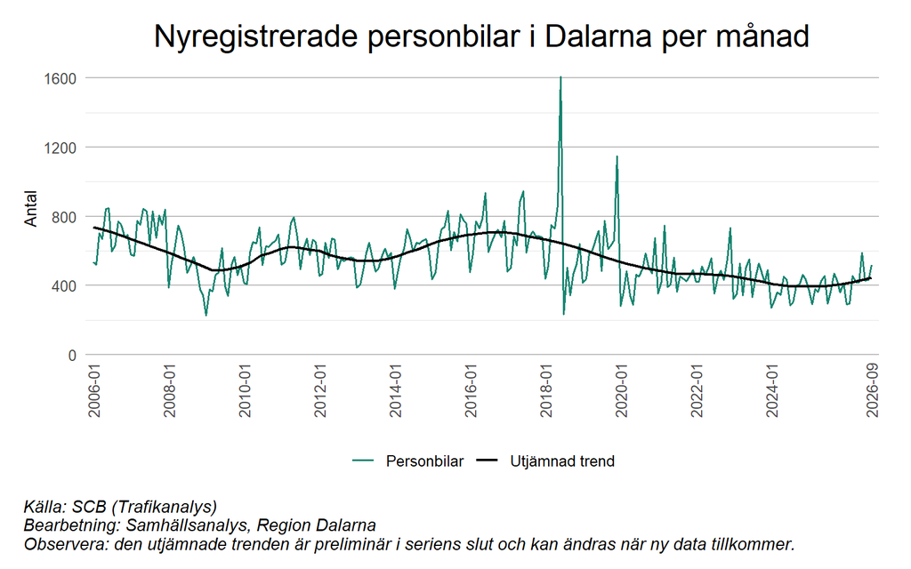

### År

Antalet nyregistrerade personbilar tenderar även att variera relativt mycket från år till år. Antalet var som högst i början av den undersökta tidsperioden (2006–2007), med 8 000–9 000 registreringar per år, innan en tydlig minskning skedde i samband med finanskrisen 2008–2009. Därefter återhämtade sig antalet och nådde en ny topp runt 2015-2017. Efter 2019 har nivån sjunkit märkbart och legat kring 4 000 nyregistreringar per år de senaste åren.

Den kraftiga nedgången sedan 2019 berodde initialt till stor del på coronapandemin och dess effekter (se [Mobility Sweden](https://mobilitysweden.se/statistik/bilismen-i-sverige/2020/nyregistreringar) och [SVT](https://www.svt.se/nyheter/lokalt/varmland/farre-bilar-bade-nya-och-begagnade)). Att nyregistreringarna därefter har legat på en fortsatt låg nivå kan ha flera olika förklaringar, däribland en högre räntenivå i samhället (se avsnittet om inflation ovan), en relativt utdragen konjunkturnedgång (se avsnittet om konjunkturbarometern) samt den slopade elbilspremien (se [SVT](https://www.svt.se/nyheter/inrikes/elbilsforsaljningen-rasar-branschen-kraver-atgarder)). Enligt flera källor har personbilar dessutom blivit betydligt dyrare på senare år, vilket sannolikt påverkar efterfrågan.

Hittills under 2026 har 3846 personbilar nyregistrerats i Dalarna, vilket dock är klart fler än de 3406 som registrerades under motsvarande period 2025. Det kan tyda på en viss återhämtning, även om nivån fortfarande är lägre än under mitten av 2010-talet.

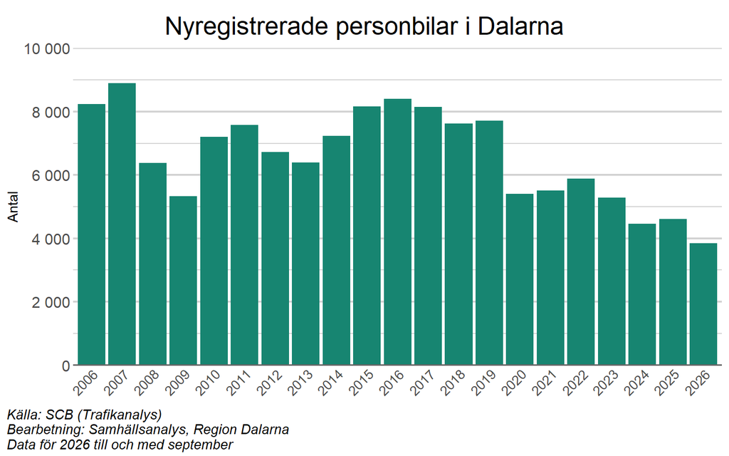

# 4 Arbetsmarknaden

Som mått på läget i Dalarna är arbetslösheten sannolikt en relativt trögrörlig indikator. Detta eftersom företag i första läget varslar personal, för att därefter eventuellt göra större uppsägningar. Det är även viktigt att notera att arbetslösheten varierar mellan olika grupper i samhället, exempelvis baserat på personers kön, utbildningsbakgrund eller huruvida de är födda i Sverige. För en fördjupad diskussion om detta, se exempelvis Region Dalarnas rapport [“Kvinnor och män i Dalarna”](https://samhallsanalys.regiondalarna.se/kvinnor_man).

## 4.1 Arbetslöshet

**Mer information om statistiken**

Arbetslöshet beräknas som andelen arbetslösa i förhållande till antalet personer i arbetskraften, det vill säga summan av antalet arbetslösa och antalet sysselsatta. Statistik över arbetslöshet och sysselsättning kan tas fram på olika sätt. Det gör att siffror som rör samma referensperiod kan skilja sig åt beroende på vilken statistikkälla som använts. I den här rapporten används BAS - befolkningens arbetsmarknadsstatus - som redovisar registerbaserad statistik över utbudet av arbetskraft i Sverige. För en diskussion runt skillnaderna mellan BAS och Arbetsförmedlingens statistik, se [SCB](https://www.scb.se/contentassets/f5d14c6270b746f6af4e5ef37886704f/en-numerisk-beskrivning-av-relationen-mellan-bas-och-arbetsformedlingens-statistik.pdf).

### Län

I en nationell jämförelse är arbetslösheten i Dalarna relativt låg. I augusti 2026 hade Dalarna 3,8 procents arbetslöshet, att jämföra med 5,2 procent i Sverige som helhet. Noterbart är även att Dalarna hade klart lägre arbetslöshet än näraliggande Gävleborg, där arbetslösheten var 6,2 procent under samma tidsperiod. Lägst arbetslöshet i Sverige hade Gotland med 2,5 procent.

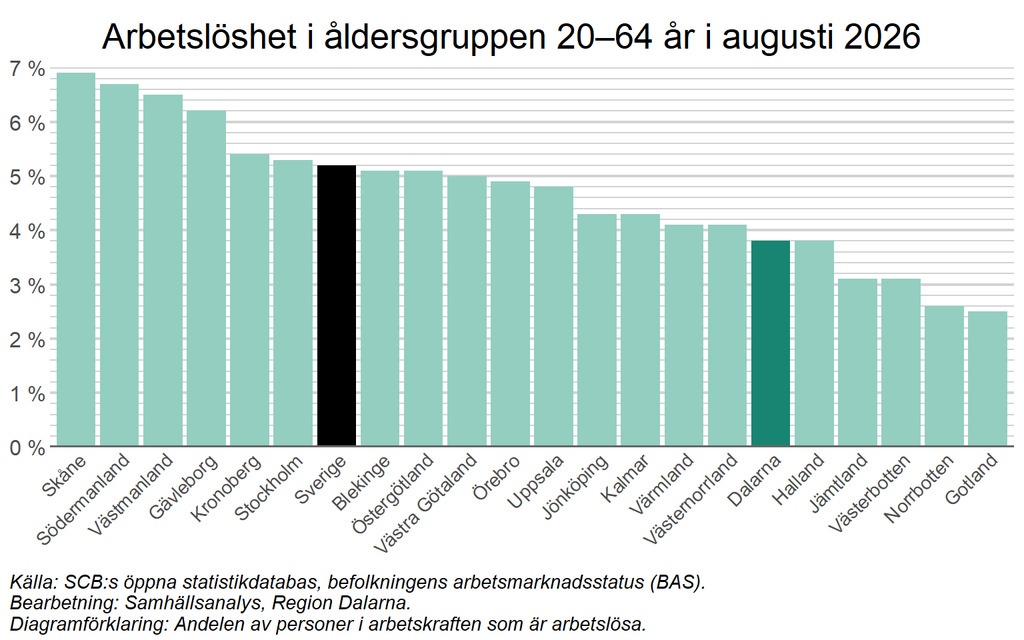

I jämförelse med motsvarande månad året innan minskade arbetslösheten i augusti 2026 i samtliga av Sveriges län utom Gotland, där den var oförändrad. I Dalarna minskade arbetslösheten med 0,2 procentenheter.

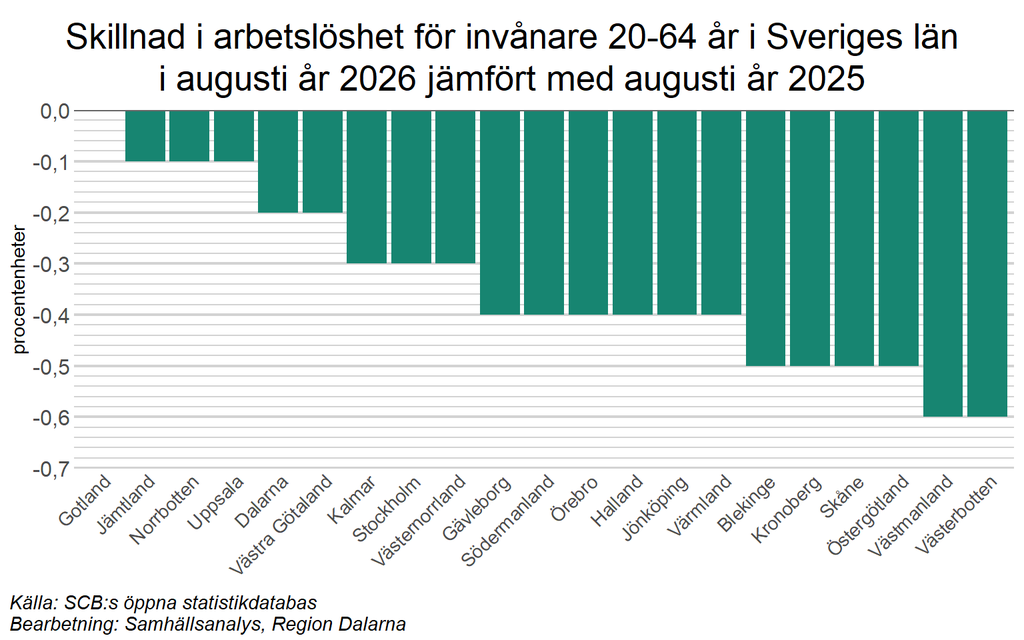

### Jämförelse över tid

Arbetslösheten, såväl i Dalarna som i Sverige, varierar över tid. I samband med coronapandemin ökade arbetslösheten och var som högst i Dalarna i januari 2021, då den uppgick till 6,3 procent. Därefter har arbetslösheten minskat och var 3,8 procent i Dalarna i augusti 2026.

Under stora delar av 2025 var arbetslösheten i Dalarna på ungefär samma nivå som motsvarande månader 2023 och 2024, men mot slutet av året var den något lägre. Denna trend har fortsatt under 2026, då arbetslösheten varit lägre än motsvarande månader åren innan.

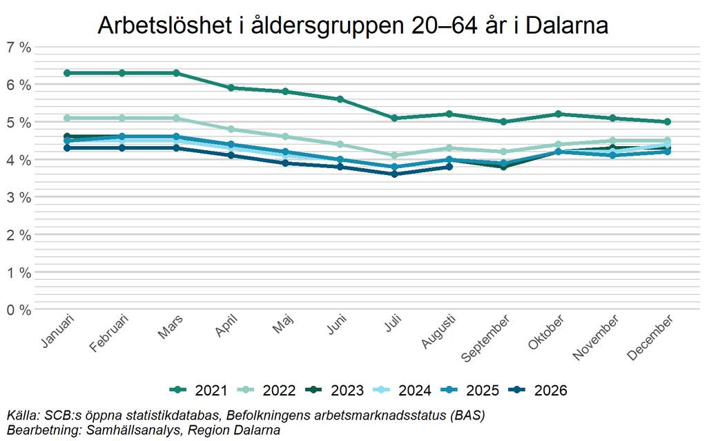

Om arbetslösheten delas upp i inrikes och utrikes födda framträder en delvis annorlunda bild. Bland inrikes födda (det vänstra diagrammet nedan) var arbetslösheten under stora delar av 2025 något högre än åren innan. I augusti 2026 uppgick den till 2,4 procent i Dalarna, vilket dock var något lägre än motsvarande månad året innan. Bland utrikes födda (det högra diagrammet nedan) har arbetslösheten minskat tydligt under samma tidsperiod, men är klart högre än bland inrikes födda (10,6 procent i augusti 2026).

Totalt var ungefär 2 680 inrikes födda personer och ungefär 2 240 utrikes födda personer i åldersgruppen 20–64 år arbetslösa i Dalarna i augusti 2026.

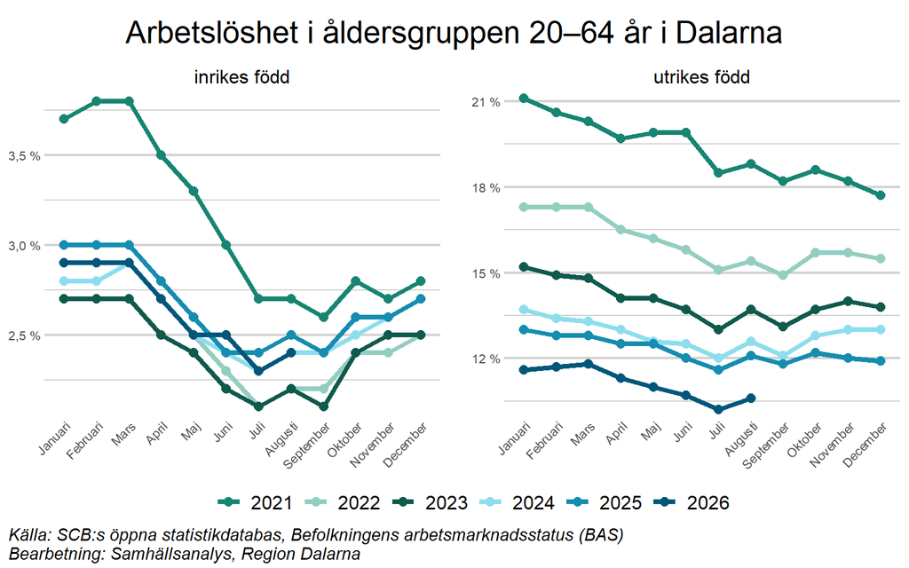

### Kommun

Arbetslösheten i Dalarnas kommuner är låg på många håll, där en majoritet av länets kommuner hade mellan 2 och 4 procents arbetslöshet i augusti 2026. Lägst var arbetslösheten i Mora, med 2,2 procent. I de södra delarna av länet är bilden delvis annorlunda, där kommunerna generellt hade högre arbetslöshet. Högst var arbetslösheten i Borlänge, där den uppgick till 5,6 procent. En tänkbar orsak till detta mönster är att de kommuner som hade högst arbetslöshet också tenderar att vara de som har högst andel utrikes födda. Som framgick i föregående flik hamnar den sistnämnda gruppen i arbetslöshet i högre utsträckning än inrikes födda.

[interactive chart not shown]

# 5 Befolkningens ekonomi

Befolkningens ekonomiska situation kan mätas på flera olika sätt. Arbetslösheten, som diskuterades i föregående avsnitt, är en indikator. Personer som arbetar har generellt en bättre ekonomi än personer som inte gör det. En annan indikator är den disponibla inkomsten, dvs. hur mycket varje person har i plånboken (inkomst efter skatt och transfereringar). Tyvärr mäts den disponibla inkomsten med en betydande eftersläpning, varför vi i denna rapport istället har valt att fokusera på hur många individer som har svårt att försörja sig, mätt i antalet personer som har ekonomiskt stöd som huvudsaklig inkomstkälla.

## 5.1 Ekonomiskt stöd

**Mer information om statistiken**

Med ekonomiskt stöd åsyftas försörjningsstöd och bistånd till livsföringen i övrigt för sökande och eventuell medsökande, bostadsbidrag för sökande och eventuell medsökande samt äldreförsörjningsstöd.

I Dalarna hade som mest närmare 5 000 personer mellan 15 och 74 år ekonomiskt stöd som huvudsaklig inkomstkälla under 2020, men därefter minskade antalet stadigt under en längre period. Anmärkningsvärt är även att antalet med stöd minskade trots att prisnivån i samhället ökade avsevärt under samma tidsperiod (se avsnittet om inflation). Exakt vad den utvecklingen beror på är oklart, men ett antal tänkbara orsaker diskuteras i följande [artikel](https://www.svt.se/nyheter/inrikes/darfor-minskar-antalet-hushall-som-far-socialbidrag-i-sverige-forskare-forklarar-orsaker-bakom).

Antalet personer som har ekonomiskt stöd som huvudsaklig inkomstkälla varierar en del mellan månaderna, men under 2025 var trenden nedåtgående jämfört med föregående år. I augusti 2026 hade ungefär 3 000 personer det, vilket var färre än månaderna innan.

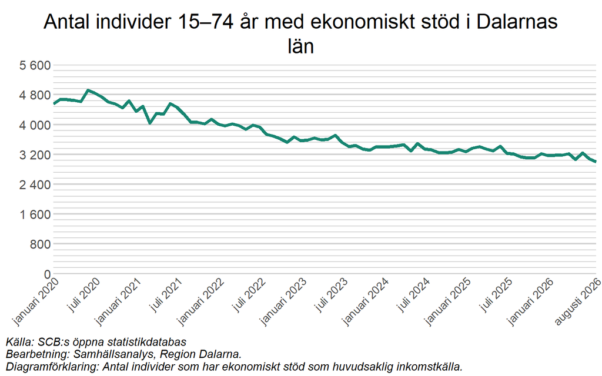

Om antalet individer delas upp i inrikes och utrikes födda blir det tydligt att nedgången framförallt är koncentrerad till utrikes födda. I januari 2020 hade ungefär 840 fler utrikes än inrikes födda personer i Dalarna ekonomiskt stöd som huvudsaklig inkomstkälla. I augusti 2026 hade istället fler inrikes födda än utrikes födda sådant stöd.

En trolig bidragande orsak till nedgången bland utrikes födda är att arbetslösheten i samma grupp minskat tydligt under perioden (se avsnittet om arbetsmarknaden), vilket innebär att färre är beroende av ekonomiskt stöd för sin försörjning.

Ett annat generellt mönster är att det bland inrikes födda är vanligare att män har ekonomiskt stöd som huvudsaklig inkomstkälla, medan det bland utrikes födda är vanligare att kvinnor har det.

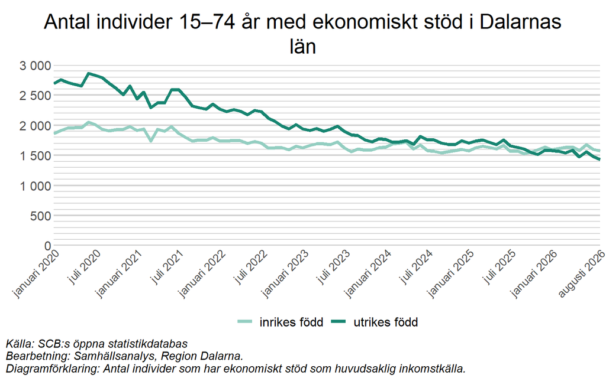